# Income v. Relationship Quality

Karl Stavem

3/2/2020

# Topic 2: How does income/income disparity affect relationship outcomes over time? And how does total income affect relationship length?

## T-Test

Hypothesis testing: Our null hypothesis is that combined income of couples of greater than $75,000 (chosen due to factors explained here: https://www.huffpost.com/entry/map-happiness-benchmark_n_5592194) has no effect on relationship length/quality. We will perform the test via a large sample Z-test or t-test since our sample size is sufficiently large for both. We will create a calculated field for combined income that adds Partner 1 Income to Partner 2 incomes.

First, we need to create a few additional fields to run our analysis.

```r
#remove NAs from the relationship quality column
df <- df[is.na(df$RELATIONSHIP_QUALITY)==FALSE,]

# clean up the income column - grab the number associated with each category
df$income_val <- as.numeric(substr(df$PPINCIMP, 2, 3))

# clean up the relationship quality column - grab the number associated with each category
df$relationship_val <- as.numeric(substr(df$RELATIONSHIP_QUALITY, 2, 2))

# create a boolean to track if couples make $75,000 or more
df$income_greater_than_75k <- as.numeric(ifelse(df$income_val >= 14, 1, 0))
```

Since have turned the income variable into a simple categorical variable with only two levels ($75k and over, or less than $75k), then the simple regression analysis is equivalent to an equal variance T test. However, we do not want wish to assume equal variance in our two groups and have selected to run a Welch T-Test.

```r
# split into two groups
more.than.75k.group <- df$relationship_val[df$income_greater_than_75k == 1]
less.than.75k.group <- df$relationship_val[df$income_greater_than_75k == 0]

# look at number in each group
length(more.than.75k.group)
```

```
## [1] 1096
```

```r
length(less.than.75k.group)
```

```
## [1] 1900
```

```r
# difference in size
length(less.than.75k.group) - length(more.than.75k.group)
```

```
## [1] 804
```

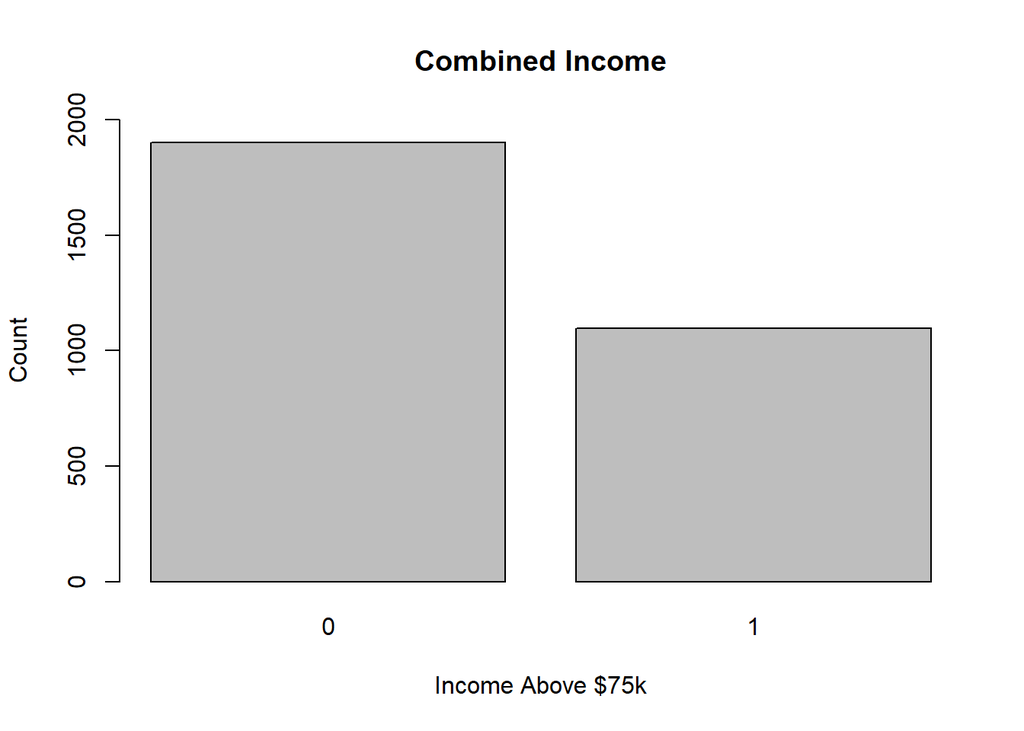

```r
# show the sizes
barplot(table(df$income_greater_than_75k),
        main = 'Combined Income',
        xlab = 'Income Above $75k',
        ylim = c(0,2000),
        ylab = 'Count'
        )
```

Are we sufficiently powered to study our data? Could we detect small difference of 20% with 90% power and a 0.05 significance level?

```r
data = df$income_greater_than_75k
mu_0 = mean(data)
mu_1 = mu_0 *.8
numerator = sd(data)^2 * (qnorm(.9) + qnorm(1-.05/2)^2)
denominator = (mu_0 - mu_1)^2
n = numerator/denominator
n
```

```
## [1] 222.1024
```

We would need at least 222.102 people in each group to accurately perform this test. We should have sufficient power.

So our null hypothesis:

$$H_0: \mu_1 = \mu_0 \\ H_A: \mu_1 > \mu_0$$

```r
# look at the results of the test - highly significant
model1 <- t.test(more.than.75k.group, less.than.75k.group, var.equal = FALSE, alternative = 'g')
model1
```

```
##
##  Welch Two Sample t-test
##
## data:  more.than.75k.group and less.than.75k.group
## t = 3.3997, df = 2410, p-value = 0.0003428
## alternative hypothesis: true difference in means is greater than 0
## 95 percent confidence interval:
##  0.04973564        Inf
## sample estimates:
## mean of x mean of y
##  4.520073  4.423684
```

Looking at the results of the t-test, we can see that having income above $75,000 is highly significant with regard to relationship quality. Here we see a very small p-value of 3.4310^{-4}.

## Linear Models

Linear regression: we will create a linear regression model using income as the predictor variable and relationship length/quality as the outcome variable and examine the strength of the income coefficient, as well as the correlation between income and relationship length.

#### Difference in income

In order to run our analysis, we will use the `diff_in_income` field that we created during our data cleansing process. This field is a simple boolean that tracks whether or not the two partners have approximately the same income level, or a different level. We can build a simple linear model comparing this to `relationsihp_quality`.

```r
# Build the linear model
model2 <- lm(relationship_val ~ diff_in_income, data=df)
model2.summary <-  summary(model2)
model2.summary
```

```
##
## Call:
## lm(formula = relationship_val ~ diff_in_income, data = df)
##
## Residuals:
##    Min     1Q Median     3Q    Max
## -3.449 -0.449  0.551  0.551  0.551
##
## Coefficients:
##                Estimate Std. Error t value Pr(>|t|)
## (Intercept)     4.51872    0.03942 114.618   <2e-16 ***
## diff_in_income -0.06974    0.04217  -1.654   0.0983 .
## ---
## Signif. codes:  0 '***' 0.001 '**' 0.01 '*' 0.05 '.' 0.1 ' ' 1
##
## Residual standard error: 0.7624 on 2969 degrees of freedom
##   (25 observations deleted due to missingness)
## Multiple R-squared:  0.0009204,  Adjusted R-squared:  0.0005839
## F-statistic: 2.735 on 1 and 2969 DF,  p-value: 0.09827
```

If we simply look at the results from this model we can see that that our p-value (0.0982715) is not below 0.05, and we *do not* see sufficient evidence to reject the null hypothesis.

There are several assumptions that are required in order to trust statistical inferences based on a linear model. In order to create an accurate linear regression model, our data needs to meet the following four assumptions:

- Independence – we worry about this when we have longitudinal dataset. Longitudinal data occurs when we collect observations from the same entity over time. In this scenario, we do have a longitudinal data set, so it might have been a concern. However, we are only looking at the original series of questions. In this case, the set of observations are independent. We have essentially narrowed our focus to a cross-sectional study and independence is assumed.
- Linearity – when we examine the data, we do not necessarily see any indication that this data follows a linear pattern. This assumption may not hold for our dataset.
- Equality of variance: We look at a scattorplot of residuals an fitted values. If the residuals do not fan out in a triangular fashion that means that the equal variance assumption is met. Looking at our data, it is unclear if this is a concern:

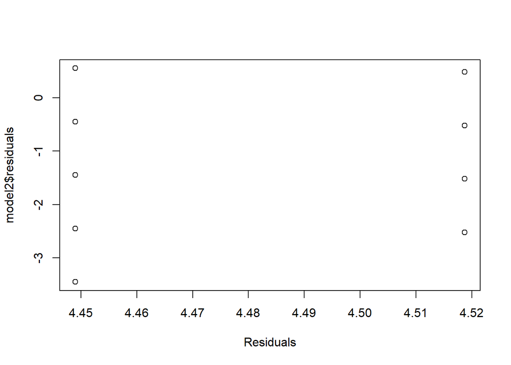

```r
plot(model2$fitted.values, model2$residuals, xlab = "Residuals")
```

- Normality: We can address the normality assumption by looking at the histogram of residuals.

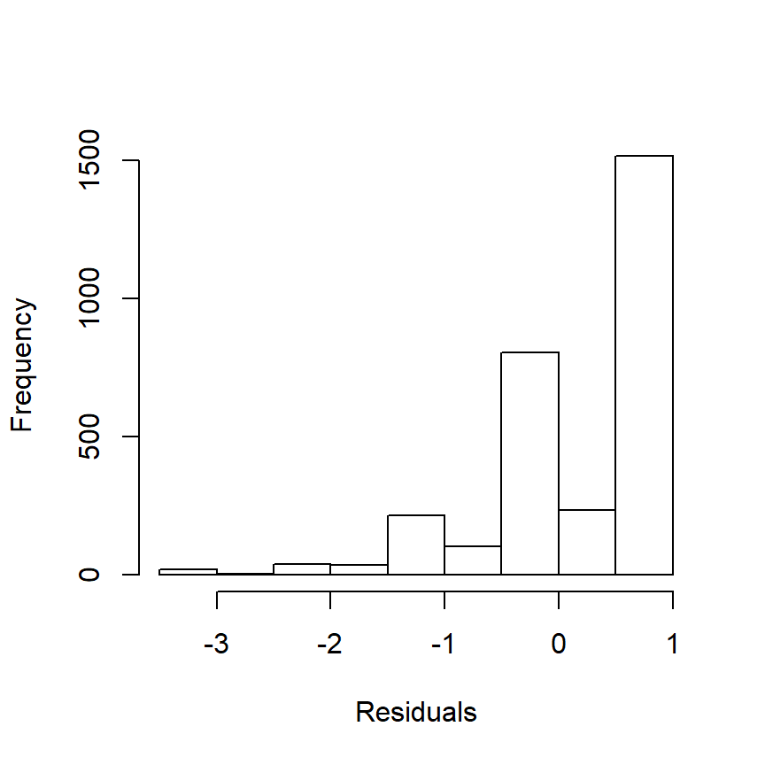

```r
hist(model2$residuals,main="", xlab = "Residuals")
```

This doesn’t appear to be very normally distributed.

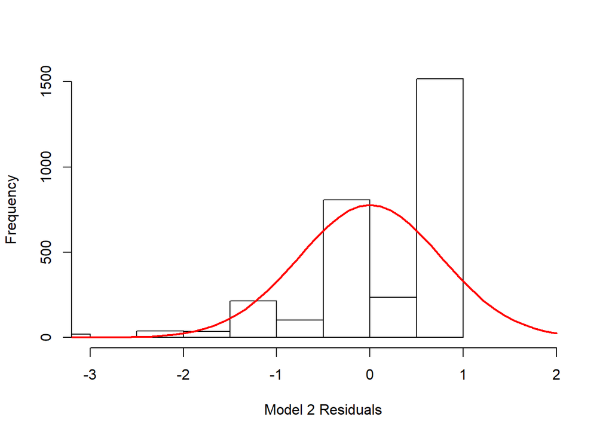

```r
x <- model2$residuals
h<-hist(x, xlab="Model 2 Residuals", ylim=c(0,1500),xlim=c(-3,2),
        main="")
xfit<-seq(min(x),2,length=50)
yfit<-dnorm(xfit,mean=mean(x),sd=sd(x))
yfit <- yfit*diff(h$mids[1:2])*length(x)
lines(xfit, yfit, col="red", lwd=2)
```

Also, looking at the Q-Q plot, we are forced to reject the normality assumption:

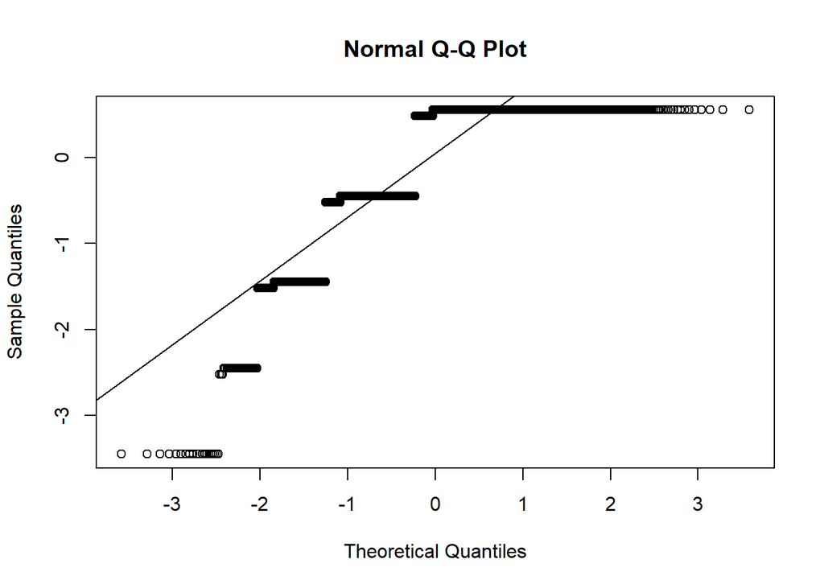

```r
qqnorm(model2$residuals)
qqline(model2$residuals)
```

Another possibility is ANOVA:

```r
model4 <- aov(relationship_val ~ diff_in_income, data=df)
summary.model4 <- summary(model4)
summary.model4
```

```
##                  Df Sum Sq Mean Sq F value Pr(>F)
## diff_in_income    1    1.6  1.5899   2.735 0.0983 .
## Residuals      2969 1725.9  0.5813
## ---
## Signif. codes:  0 '***' 0.001 '**' 0.01 '*' 0.05 '.' 0.1 ' ' 1
## 25 observations deleted due to missingness
```

However, in this scenario, we are simply comparing two groups. Because of this, ANOVA provides the exact same results as linear regression. Looking at the p-value of this model, we can see a value of 0.0983. Therefore, we do not see sufficient evidence to reject the null hypothesis that difference in income has no effect on mean relationship quality.

We could try flipping the question around and see if relationship quality is able to tell us anything about the likelihood of having different income. Here, we can use a logistic regression:

```r
model5 <- summary(glm(diff_in_income ~ relationship_val, data=df, family = binomial))
model5$coef
```

```
##                    Estimate Std. Error   z value     Pr(>|z|)
## (Intercept)       2.5071139 0.35104832  7.141791 9.212231e-13
## relationship_val -0.1269331 0.07684886 -1.651723 9.859095e-02
```

```r
model5.coeff <- exp(model5$coefficients['relationship_val', 'Estimate'])
model5.coeff
```

```
## [1] 0.8807926
```

Here we can say that with each unit increase in relationship quality, the odds of having different income as a couple decrease by a factor of 0.881.

#### Income levels

In this model we will ignore differences in income between partners. Instead we will simply look at the total combined income for the couple.

ANOVA to analysis the results:

```r
model7 <- aov(relationship_val ~ factor(income_val), data = df)
summary.model7 <- summary(model7)
summary.model7
```

```
##                      Df Sum Sq Mean Sq F value   Pr(>F)
## factor(income_val)   18   26.8  1.4867   2.583 0.000271 ***
## Residuals          2977 1713.2  0.5755
## ---
## Signif. codes:  0 '***' 0.001 '**' 0.01 '*' 0.05 '.' 0.1 ' ' 1
```